# Análisis de Datos de Fútbol — Caso Práctico

Marcel Andrés Palma Céspedes

16 noviembre 2025

# 📊 Análisis de Datos de Fútbol — Caso Práctico

IMMUNE Technology Institute — Informe interactivo (R Notebook)

# Introducción

Este proyecto busca realizar un análisis exploratorio y predictivo de los datos de rendimiento de jugadores de fútbol, utilizando **R** como herramienta principal.

**Objetivos principales:** - Analizar patrones en variables de rendimiento (goles, minutos, posiciones, etc.). - Construir un modelo de regresión para predecir una variable objetivo. - Evaluar el modelo con métricas estadísticas (RMSE, R²). - Aplicar ANOVA y comparaciones múltiples (Tukey) para contrastar grupos.

# 📊 Paso 1 (Código): instalar y cargar librerías + configurar opciones

```r
# Paso 1: instalar y cargar librerías + configurar opciones

# Instalar paquetes si no existen (ejecuta sólo la primera vez)
required_pkgs <- c(
  "tidyverse", "readxl", "janitor", "skimr", "GGally",
  "caret", "broom", "generics", "vctrs", "dplyr", "AER", "car","pscl", "ggplot2", "data.table", "patchwork", "multcomp", "kableExtra"
)

new_pkgs <- required_pkgs[!(required_pkgs %in% installed.packages()[, "Package"])]
if (length(new_pkgs) > 0) install.packages(new_pkgs)

# Cargar librerías
suppressPackageStartupMessages({
  library(knitr)
  library(pscl)
  library(generics)
  library(AER)
  library(kableExtra)
  library(tidyverse)
  library(readxl)
  library(vctrs)
  library(dplyr)
  library(janitor)
  library(skimr)
  library(GGally)
  library(caret)
  library(broom)
  library(car)
  library(patchwork)
  library(multcomp)
  library(data.table)
})

# Opciones estéticas y reproducibilidad
options(stringsAsFactors = FALSE)
set.seed(123)
theme_set(theme_minimal())
```

## 🧩 Comprobación de librerías

```r
# Verifica que los paquetes se cargan sin error
library(tidyverse)
library(readxl)
library(janitor)
library(skimr)
library(GGally)
library(caret)
library(broom)
library(car)
library(patchwork)
library(multcomp)
library(data.table)
```

# 🪶 Paso 2: Cargar y explorar la base de datos

```r
ruta <- "C:/Users/Marcel Palma/Desktop/IMMUNE/6. Asignatura 6  Estadística para científicos de datos Programación en R/Case to be solved/df_futbol.xlsx"

# Leer el archivo Excel y limpiar nombres de columnas
df <- read_excel(ruta) %>%
  clean_names()
```

```r
# Mostrar las primeras filas del dataset
head(df)
```

| jugador | clasificacion | club | posicion | edad | partidos_jugados | titular | min | goles | asistencias | penalti_ejecutados | penalti_intentados | tarjetas_amarillas | tarjetas_rojas | total_disparos_juego | x16 |
| --- | --- | --- | --- | --- | --- | --- | --- | --- | --- | --- | --- | --- | --- | --- | --- |
| Jan Oblak | 1 | Atlético de Madrid | PO | 27 | 38 | 38 | 3420 | 0 | 0 | 0 | 0 | 0 | 0 | 0 | 3420 |
| Koke | 1 | Atlético de Madrid | CC | 28 | 37 | 34 | 3021 | 1 | 2 | 0 | 0 | 9 | 0 | 17 | 3330 |
| Marcos Llorente | 1 | Atlético de Madrid | CC_DL | 25 | 37 | 33 | 2956 | 12 | 11 | 0 | 0 | 6 | 0 | 49 | 3330 |
| Stefan Savic | 1 | Atlético de Madrid | DF | 29 | 33 | 33 | 2953 | 1 | 0 | 0 | 0 | 14 | 0 | 7 | 2970 |
| Mario Hermoso | 1 | Atlético de Madrid | DF | 25 | 31 | 30 | 2578 | 1 | 1 | 0 | 0 | 6 | 0 | 18 | 2790 |
| Luis Suárez | 1 | Atlético de Madrid | DL | 33 | 32 | 30 | 2508 | 21 | 3 | 3 | 3 | 6 | 0 | 101 | 2880 |

```r
# Ver el número de filas y columnas
dim(df)
```

```
[1] 582  16
```

```r
# Ver los nombres de las columnas
names(df)
```

```
 [1] "jugador"              "clasificacion"        "club"                 "posicion"
 [5] "edad"                 "partidos_jugados"     "titular"              "min"
 [9] "goles"                "asistencias"          "penalti_ejecutados"   "penalti_intentados"
[13] "tarjetas_amarillas"   "tarjetas_rojas"       "total_disparos_juego" "x16"
```

# 🪶 Paso 3 — Limpieza y preparación inicial de datos

En esta etapa se revisa la calidad de los datos y se crean variables derivadas que servirán para el análisis exploratorio y la modelización. Se examinan los valores faltantes, duplicados y se generan nuevas variables como la razón de goles por 90 minutos de juego.

```r
# Paso 3: Limpieza y preparación inicial de datos

# 1. Revisar valores faltantes (NA)
colSums(is.na(df))
```

```
             jugador        clasificacion                 club             posicion                 edad
                   0                    0                    0                    0                    0
    partidos_jugados              titular                  min                goles          asistencias
                   0                    0                    0                    0                    0
  penalti_ejecutados   penalti_intentados   tarjetas_amarillas       tarjetas_rojas total_disparos_juego
                   0                    0                    0                    0                    0
                 x16
                 550
```

```r
# 2. Verificar si existen filas duplicadas
duplicados <- df[duplicated(df), ]
nrow(duplicados)
```

```
[1] 0
```

```r
# 3. Crear variables derivadas útiles para el análisis
#    (solo si las columnas necesarias existen y no tienen NA críticos)

df <- df %>%
  mutate(
    # Goles por 90 minutos jugados
    goles_por_90 = if_else(min > 0, (goles / min) * 90, NA_real_),

    # Asistencias por 90 minutos jugados
    asistencias_por_90 = if_else(min > 0, (asistencias / min) * 90, NA_real_),

    # Porcentaje de partidos jugados como titular
    pct_titular = if_else(partidos_jugados > 0, (titular / partidos_jugados) * 100, NA_real_)
  )

# 4. Verificar que las nuevas columnas se hayan creado correctamente
glimpse(df)
```

```
Rows: 582
Columns: 19
$ jugador              <chr> "Jan Oblak", "Koke", "Marcos Llorente", "Stefan Savic", "Mario Hermoso", "Luis S…
$ clasificacion        <dbl> 1, 1, 1, 1, 1, 1, 1, 1, 1, 1, 1, 1, 1, 1, 1, 1, 1, 1, 1, 1, 1, 1, 1, 1, 1, 2, 2,…
$ club                 <chr> "Atlético de Madrid", "Atlético de Madrid", "Atlético de Madrid", "Atlético de M…
$ posicion             <chr> "PO", "CC", "CC_DL", "DF", "DF", "DL", "DL_CC", "DF", "DF_CC", "DF", "CC_DF", "D…
$ edad                 <dbl> 27, 28, 25, 29, 25, 33, 25, 29, 26, 31, 25, 25, 24, 20, 22, 30, 28, 27, 24, 30, …
$ partidos_jugados     <dbl> 38, 37, 37, 33, 31, 32, 38, 28, 30, 31, 33, 21, 27, 31, 23, 16, 9, 25, 19, 10, 7…
$ titular              <dbl> 38, 34, 33, 33, 30, 30, 29, 28, 25, 23, 22, 20, 19, 14, 11, 8, 6, 4, 3, 3, 2, 2,…
$ min                  <dbl> 3420, 3021, 2956, 2953, 2578, 2508, 2393, 2475, 2179, 2057, 2033, 1765, 1366, 15…
$ goles                <dbl> 0, 1, 12, 1, 1, 21, 9, 0, 6, 0, 2, 0, 1, 7, 1, 0, 0, 0, 1, 0, 2, 0, 0, 0, 0, 0, …
$ asistencias          <dbl> 0, 2, 11, 0, 1, 3, 8, 6, 10, 0, 1, 0, 3, 5, 2, 1, 0, 0, 0, 0, 0, 0, 1, 0, 0, 0, …
$ penalti_ejecutados   <dbl> 0, 0, 0, 0, 0, 3, 0, 0, 0, 0, 0, 0, 0, 1, 0, 0, 0, 0, 0, 0, 1, 0, 0, 0, 0, 0, 1,…
$ penalti_intentados   <dbl> 0, 0, 0, 0, 0, 3, 0, 0, 0, 0, 1, 0, 0, 2, 0, 0, 0, 0, 0, 0, 1, 0, 0, 0, 0, 0, 1,…
$ tarjetas_amarillas   <dbl> 0, 9, 6, 14, 6, 6, 3, 0, 6, 8, 10, 5, 4, 6, 3, 2, 2, 4, 2, 2, 1, 1, 0, 0, 0, 0, …
$ tarjetas_rojas       <dbl> 0, 0, 0, 0, 0, 0, 0, 0, 0, 0, 0, 0, 0, 0, 0, 0, 0, 0, 0, 0, 0, 0, 0, 0, 0, 0, 0,…
$ total_disparos_juego <dbl> 0, 17, 49, 7, 18, 101, 52, 3, 43, 12, 32, 14, 23, 37, 11, 7, 0, 5, 3, 2, 4, 5, 0…
$ x16                  <dbl> 3420, 3330, 3330, 2970, 2790, 2880, 3420, 2520, 2700, 2790, 2970, 1890, 2430, 27…
$ goles_por_90         <dbl> 0.00000000, 0.02979146, 0.36535859, 0.03047748, 0.03491078, 0.75358852, 0.338487…
$ asistencias_por_90   <dbl> 0.00000000, 0.05958292, 0.33491204, 0.00000000, 0.03491078, 0.10765550, 0.300877…
$ pct_titular          <dbl> 100.00000, 91.89189, 89.18919, 100.00000, 96.77419, 93.75000, 76.31579, 100.0000…
```

## 🧩 Verificación rápida (solo para comprobar)

```r
summary(df$min)
```

```
   Min. 1st Qu.  Median    Mean 3rd Qu.    Max.
    1.0   390.8  1176.0  1289.7  2115.0  3420.0
```

```r
summary(df$goles_por_90)
```

```
   Min. 1st Qu.  Median    Mean 3rd Qu.    Max.
0.00000 0.00000 0.00000 0.09293 0.12274 2.04545
```

```r
summary(df$asistencias_por_90)
```

```
   Min. 1st Qu.  Median    Mean 3rd Qu.    Max.
0.00000 0.00000 0.00000 0.07188 0.10493 3.00000
```

# 🚀 Paso 4: Análisis Exploratorio (EDA)

Gráficos y resumen con ggplot2 y GGall (informe estilo html)

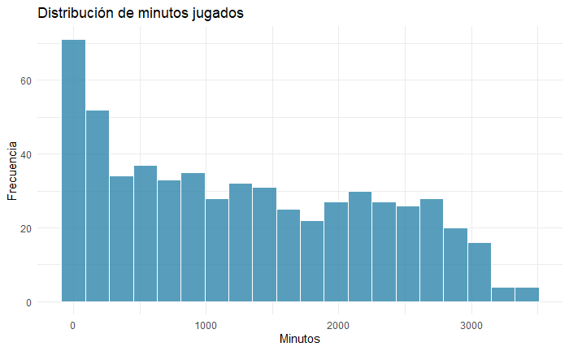

```r
# Distribución de minutos jugados
ggplot(df, aes(x = min)) +
  geom_histogram(bins = 20, fill = "#2E86AB", color = "white", alpha = 0.8) +
  labs(title = "Distribución de minutos jugados", x = "Minutos", y = "Frecuencia")
```

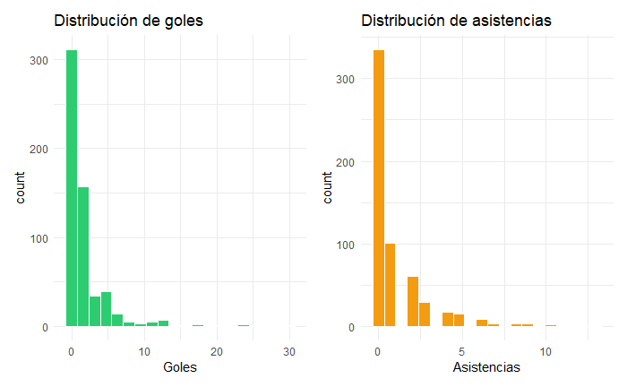

```r
# Distribución de goles y asistencias
p1 <- ggplot(df, aes(x = goles)) +
  geom_histogram(bins = 20, fill = "#2ECC71", color = "white") +
  labs(title = "Distribución de goles", x = "Goles")

p2 <- ggplot(df, aes(x = asistencias)) +
  geom_histogram(bins = 20, fill = "#F39C12", color = "white") +
  labs(title = "Distribución de asistencias", x = "Asistencias")

# Mostrar ambos histogramas juntos
p1 + p2
```

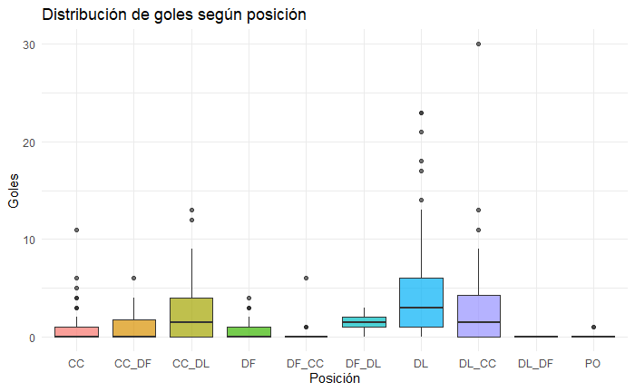

```r
# Boxplot comparando goles por posición
ggplot(df, aes(x = posicion, y = goles, fill = posicion)) +
  geom_boxplot(alpha = 0.7) +
  labs(title = "Distribución de goles según posición", x = "Posición", y = "Goles") +
  theme(legend.position = "none")
```

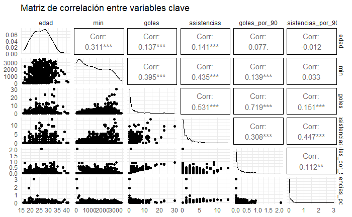

```r
# Correlación entre variables numéricas (usando dplyr::select para evitar conflictos)
df %>%
  dplyr::select(edad, min, goles, asistencias, goles_por_90, asistencias_por_90) %>%
  GGally::ggpairs(title = "Matriz de correlación entre variables clave")
```

## 📊 Interpretación del primer gráfico de histograma:(Minutos jugados)

### DISTRIBUCIÓN DE MINUTOS JUGADOS

- Distribución asimétrica con sesgo positivo
- Pico principal de alta frecuencia alrededor de los 0-500 minutos
- Cola larga extenida hasta los 3000 minutos
- Jugadores con pocos minutos, concentrados en el extremo izquierdo. Muchos con participación limitada
- Jugadores titulares con obvia frecuencia más baja y constante entre 1500 y 3000 minutos
- Brecha notable por disminución abrupta después del pico inicial, refleja clara división entre suplentes y titulares
- Polarización en el uso de jugadores
- Muchos de estos tienen roles secundarios o de rotación
- Pocos alcanzan los 3000 minutos (equivalente a ≈33 a 35 partidos completos)

## 📊 Interpretación del tercer gráfico boxplot: (Goles por Posición)

### ANÁLISIS POR POSICIÓN:

🛡️ POSICIONES DEFENSIVAS:

- DF (Defensas puros): Muy baja productividad goleadora
- DF_CC, DF_DL: Ligeramente mejor pero aún baja
- PO (Porteros): Casi nula contribución goleadora por obvias razones

## 📊 Interpretación de la Matriz de Correlación

La matriz muestra la relación entre seis variables clave: **edad**, **min** (minutos jugados), **goles** (totales), **asistencias**, **goles_por_90** (goles por 90 minutos) y **asistencias_por_90** (asistencias por 90 minutos).

### A. Correlaciones de Rendimiento Total (Goles y Asistencias)

| Variables | Correlación (r) | Significado |
| --- | --- | --- |
| **Goles vs Asistencias** | 0.531*** | 🔹 Fuerte correlación positiva. Los jugadores que marcan muchos goles también tienden a dar muchas asistencias, lo que sugiere una productividad ofensiva integral. |
| **Minutos vs Goles** | 0.395*** | 🔹 Correlación positiva moderada. Cuantos más minutos juega un jugador, más oportunidades tiene de marcar. |
| **Minutos vs Asistencias** | 0.435*** | 🔹 Correlación positiva moderada-fuerte. El tiempo en cancha influye incluso más en la acumulación de asistencias que de goles. |

> 💡 *Los asteriscos (***) indican significancia estadística (p < 0.001).*

🏆 En las correlaciones de rendimiento total se confirma que el rendimiento ofensivo es integral y está impulsado por la participación. - Productividad ofensiva unificada (r=0.531): Los jugadores que marcan muchos goles también son los que más asisten. Sugiere que la habilidad ofensiva es una cualidad completa, no se limita sólo a finalizar o crear el juego. - Importancia del tiempo de juego: Correlación moderada - fuerte entre minutos y estadísticas totales de goles (r=0.395) y asistencias (r=0.435). - Para acumular grandes números la condición básica es ser jugador titular habitual.

### B. Correlaciones de Eficiencia (Por cada 90 minutos)

Estas variables miden la **eficiencia**, independientemente de cuántos minutos haya jugado el jugador.

[output not shown]

### 🧓 C. Correlaciones con la Edad

| Variables | Correlación (r) | Significado |
| --- | --- | --- |
| **Edad vs Minutos** | 0.311*** | 🔹 Correlación baja-moderada. Los jugadores más veteranos tienden a jugar más minutos, posiblemente por confianza o experiencia. |
| **Edad vs Goles** | 0.137*** | 🔹 Relación positiva débil. |
| **Edad vs Asistencias** | 0.141*** | 🔹 Relación positiva débil. |
| **Edad vs Goles_por_90** | 0.077 | 🔸 Correlación casi nula. |
| **Edad vs Asistencias_por_90** | −0.012 | 🔸 Correlación nula o irrelevante. |

> 🧠 **Conclusión sobre la Edad:** La edad no tiene un efecto claro sobre la eficiencia; aunque los jugadores mayores juegan más minutos, su rendimiento por 90 minutos es similar al de los jóvenes.

🧓 Correlaciones con Edad: Se evalúa el impacto de la experiencia en el rendimiento. - La Experiencia da minutos: Correlación positiva débil con Minutos (r=0.311). Los jugadores más experimentados dentro del rango de la liga tienden a ser los que más minutos de juego acumulan (son la base del equipo). - La Edad no define eficiencia: Correlaciones con las métricas por_90 (Goles_por_90:r=0.077; Asistencias_por_90: r=-0.012) son prácticamente nulas. La efectividad y la calidad del rendimiento de un jugador en la liga española (según tasa por 90 minutos) no dependen de la edad. Los jóvenes talentos pueden ser tan eficientes como los veteranos consolidados.

### 🎯 Conclusión General del Gráfico

- ⚽ **Productividad ofensiva integral:** La correlación entre goles y asistencias (r = 0.531***) es la más alta entre los totales, mostrando que el talento ofensivo suele ser completo.
- ⏱️ **La cantidad impulsa al total:** Las correlaciones moderadas con los minutos confirman que el volumen de juego determina la acumulación de goles y asistencias.
- 👴 **La edad no es un factor de eficiencia:** Aunque la experiencia influye en el tiempo jugado, la productividad por 90 minutos no depende significativamente de la edad.

💬 *En resumen:* - El rendimiento total está impulsado por la participación en cancha - La eficiencia es una cualidad más individual y estable, independiente de la edad. - La participación ofensiva es un rasgo completo (goles y asistencias de la mano). - El rendimiento ofensivo altamente polarizado (pocos jugadores acumulan grandes números). - La edad está más relacionada con ser titular y acumular minutos que con la eficiencia del rendimiento en el campo.

# ⚙️ PASO 5 – Modelado de Regresión Múltiple

## 🧩 1️⃣ Definir el objetivo y preparar los datos

```r
# Objetivo: Predecir los goles de un jugador en función de sus características. Analizar la cantidad de goles en función de las variables relevantes del jugador (edad, minutos jugados, asistencias y posición).

# Seleccionamos las variables más relevantes
modelo_df <- df %>%
  dplyr::select(goles, edad, min, asistencias, posicion) %>%
  mutate(posicion = as.factor(posicion))  # Convertimos posición a variable categórica

# Verificar estructura
glimpse(modelo_df)
```

```
Rows: 582
Columns: 5
$ goles       <dbl> 0, 1, 12, 1, 1, 21, 9, 0, 6, 0, 2, 0, 1, 7, 1, 0, 0, 0, 1, 0, 2, 0, 0, 0, 0, 0, 23, 6, 5,…
$ edad        <dbl> 27, 28, 25, 29, 25, 33, 25, 29, 26, 31, 25, 25, 24, 20, 22, 30, 28, 27, 24, 30, 31, 27, 1…
$ min         <dbl> 3420, 3021, 2956, 2953, 2578, 2508, 2393, 2475, 2179, 2057, 2033, 1765, 1366, 1572, 1129,…
$ asistencias <dbl> 0, 2, 11, 0, 1, 3, 8, 6, 10, 0, 1, 0, 3, 5, 2, 1, 0, 0, 0, 0, 0, 0, 1, 0, 0, 0, 9, 4, 3, …
$ posicion    <fct> PO, CC, CC_DL, DF, DF, DL, DL_CC, DF, DF_CC, DF, CC_DF, DF, CC, DL_CC, DF_DL, CC, DL_DF, …
```

💡 Se escoge la variable dependiente (goles) 💡 Independientes: edad, minutos, asistencias y posición 💡 Se convierte posición en factor (porque es categórica)

## ✂️ 2️⃣ Dividir en conjuntos de entrenamiento y prueba (Train & Test)

Con “caret” dividir datos (80 % entrenamiento y 20 % prueba):

```r
set.seed(123)  # Reproducibilidad

# Dividir datos en train (80%) y test (20%)
indice <- createDataPartition(modelo_df$goles, p = 0.8, list = FALSE)
train_data <- modelo_df[indice, ]
test_data  <- modelo_df[-indice, ]

# Revisar dimensiones
dim(train_data)
```

```
[1] 467   5
```

```r
dim(test_data)
```

```
[1] 115   5
```

Se asegura que el modelo se entrene y evalúe con datos distintos y evitar el sobreajuste.

## 📊 3️⃣ Entrenar el modelo de regresión múltiple

Ajuste del modelo lineal (lm) con variables predictoras:

```r
# Entrenamos un modelo de regresión lineal múltiple
modelo_goles <- lm(goles ~ edad + min + asistencias + posicion, data = train_data)

# Resumen del modelo
summary(modelo_goles)
```

```
Call:
lm(formula = goles ~ edad + min + asistencias + posicion, data = train_data)

Residuals:
    Min      1Q  Median      3Q     Max
-6.6023 -1.1560 -0.0996  0.9458 21.0095

Coefficients:
                Estimate Std. Error t value Pr(>|t|)
(Intercept)   -1.7615535  0.6449795  -2.731 0.006557 **
edad           0.0308838  0.0248854   1.241 0.215231
min            0.0010050  0.0001382   7.274 1.54e-12 ***
asistencias    0.5216146  0.0700015   7.451 4.70e-13 ***
posicionCC_DF  0.5241649  0.6641015   0.789 0.430358
posicionCC_DL  1.4237359  0.4027131   3.535 0.000449 ***
posicionDF    -0.3133953  0.3082713  -1.017 0.309875
posicionDF_CC -0.0055380  0.6110298  -0.009 0.992773
posicionDF_DL -0.9149000  1.0773471  -0.849 0.396209
posicionDL     3.5920500  0.3735706   9.615  < 2e-16 ***
posicionDL_CC  2.0000792  0.4328704   4.621 4.99e-06 ***
posicionDL_DF  0.7931394  1.3722129   0.578 0.563550
posicionPO    -0.5049934  0.4776183  -1.057 0.290930
---
Signif. codes:  0 ‘***’ 0.001 ‘**’ 0.01 ‘*’ 0.05 ‘.’ 0.1 ‘ ’ 1

Residual standard error: 2.335 on 454 degrees of freedom
Multiple R-squared:  0.4861,    Adjusted R-squared:  0.4725
F-statistic: 35.79 on 12 and 454 DF,  p-value: < 2.2e-16
```

⚙️ Estructura del modelo goles = β₀ + β₁(edad) + β₂(min) + β₃(asistencias) + β₄(posición) + ε